```python
import numpy as np
from scipy.special import comb
import pandas as pd
import matplotlib.pyplot as plt
import seaborn as sns

from scipy.stats import norm, t, geom, binom, poisson, uniform, expon
```

# Zadanie 1

W urnie znajduje się 8 kul ponumerowanych od 1 do 8. Losujemy jednocześnie 5 kul. Niech X oznacza największy spośród numerów kul w wylosowanej próbce. Wyznacz rozkładd x (w ramce ddanych) oraz stwórz wykres tego rozkładu oraz jego dystrybuante. Można wykorzystać funkcję ecdf(). Wskazówka - korzytając z ecdf należy odpowiedio przygotować dane (próbkę) bazując na prawdopodbieństwie. Funkcja ecdf() to funckja wyznaczająca dystry- buantę empiryczną czy taką, która bazuje na próbce jaką mamy. Jest ona przybliżeniem dystrybuanty teoretycznej.

```python
N = 8
n = 5
X = np.arange(5,
              9)  #losujemy 5 kul bez zwracania więc najmniejszy numer kuli to może być 5 czyli największy numer kuli może być od 5 do 8

total_combinations = comb(N, n)
probabilities = comb(X - 1, n - 1) / total_combinations

df = pd.DataFrame({
    'X': X,
    'P(X=x)': probabilities,
    'CDF': np.cumsum(probabilities)
})
```

```python
df
```

|  | X | P(X=x) | CDF |
| --- | --- | --- | --- |
| 0 | 5 | 0.017857 | 0.017857 |
| 1 | 6 | 0.089286 | 0.107143 |
| 2 | 7 | 0.267857 | 0.375000 |
| 3 | 8 | 0.625000 | 1.000000 |

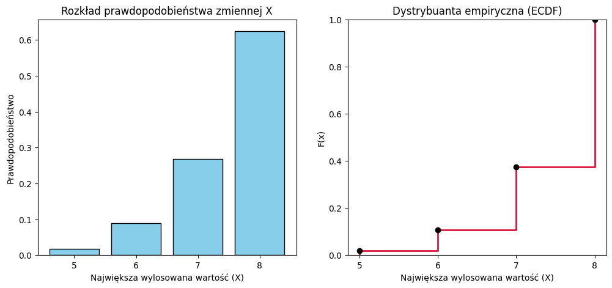

```python
counts = (probabilities * total_combinations).astype(int)
sample = np.repeat(X, counts)

fig, axes = plt.subplots(1, 2, figsize=(12, 5))
axes[0].bar(X, probabilities, color='skyblue', edgecolor='black')
axes[0].set_title('Rozkład prawdopodobieństwa zmiennej X')
axes[0].set_xlabel('Największa wylosowana wartość (X)')
axes[0].set_ylabel('Prawdopodobieństwo')
axes[0].set_xticks(X)

sns.ecdfplot(data=sample, ax=axes[1], color='crimson', linewidth=2)
plt.scatter(X, df['CDF'], color='black', label='Dystrybuanta teoretyczna', zorder=5)
axes[1].set_title('Dystrybuanta empiryczna (ECDF)')
axes[1].set_xlabel('Największa wylosowana wartość (X)')
axes[1].set_ylabel('F(x)')
axes[1].set_xticks(X)
```

# Zadanie 2

Wyznaczyć dla rozkładu normalnego o średniej 2 i odchyleniu standardowym 5 wartość funkcji gęstości w punkcie 3, wartość dystrybuanty w pukcie 7, podać kwantyl rzędu 4/5 i podać do powyższych przypadków interpretację. Powtórzyć to dla rozkładu t-studenta o 5 stopniach swoboy

```python
mu = 2
sigma = 5
x = 3
pdf_normal = norm.pdf(x, loc=mu, scale=sigma)
cdf_normal = norm.cdf(7, loc=mu, scale=sigma)
quantile_normal = norm.ppf(0.8, loc=mu, scale=sigma)
print(f'Rozkład normalny (mu={mu}, sigma={sigma}):')
print(f'Gęstość w punkcie {x}: {pdf_normal}')
print(f'Dystrybuanta w punkcie 7: {cdf_normal}')
print(f'Kwantyl rzędu 4/5: {quantile_normal}')
```

```
Rozkład normalny (mu=2, sigma=5):
Gęstość w punkcie 3: 0.07820853879509118
Dystrybuanta w punkcie 7: 0.8413447460685429
Kwantyl rzędu 4/5: 6.208106167864571
```

```python
# Rozkład t-studenta
df = 5
pdf_t = t.pdf(x, df, loc=mu, scale=sigma)
cdf_t = t.cdf(7, df, loc=mu, scale=sigma)
quantile_t = t.ppf(0.8, df, loc=mu, scale=sigma)
print(f'\nRozkład t-studenta (df={df}, mu=2, sigma=5):')
print(f'Gęstość w punkcie {x}: {pdf_t}')
print(f'Dystrybuanta w punkcie 7: {cdf_t}')
print(f'Kwantyl rzędu 4/5: {quantile_t}')
```

```
Rozkład t-studenta (df=5, mu=2, sigma=5):
Gęstość w punkcie 3: 0.0741279955427939
Dystrybuanta w punkcie 7: 0.8183912661754387
Kwantyl rzędu 4/5: 6.597718901181629
```

W porównaniu rozkładu normalnego i t-Studenta widać, że gęstość w punkcie 3 jest nieco niższa dla t-Studenta, co wynika z grubszych ogonów tego rozkładu. Dystrybuanta w punkcie 7 jest mniejsza dla t-Studenta (0,818) niż dla rozkładu normalnego (0,841), co pokazuje większe prawdopodobieństwo wartości ekstremalnych w t-Studencie. Kwantyl 0,8 dla t-Studenta jest wyższy niż dla normalnego, co również świadczy o większej rozpiętości wartości

# Zadanie 3

Obliczyć P (X ≤ 1, 5) oraz P (|X | < 2, 5) jeżeli zmienna losowa X ma rozkład N(0,1) i N(2,1)

```python
mu_1 = 0
sigma_1 = 1

mu_2 = 2
sigma_2 = 1

x1 = 1.5
x2 = 2.5
```

```python
prob1_normal_1 = norm.cdf(x1, loc=mu_1, scale=sigma_1)
prob2_normal_1 = norm.cdf(x2, loc=mu_1, scale=sigma_1) - norm.cdf(-x2, loc=mu_1, scale=sigma_1)

prob1_normal_2 = norm.cdf(x1, loc=mu_2, scale=sigma_2)
prob2_normal_2 = norm.cdf(x2, loc=mu_2, scale=sigma_2) - norm.cdf(-x2, loc=mu_2, scale=sigma_2)
```

```python
results = pd.DataFrame({
    'Rozkład': ['N(0,1)', 'N(2,1)'],
    'P(X ≤ 1.5)': [prob1_normal_1, prob1_normal_2],
    'P(|X| < 2.5)': [prob2_normal_1, prob2_normal_2]
}
)
results
```

|  | Rozkład | P(X ≤ 1.5) | P(\|X\| < 2.5) |
| --- | --- | --- | --- |
| 0 | N(0,1) | 0.933193 | 0.987581 |
| 1 | N(2,1) | 0.308538 | 0.691459 |

# Zadanie 4

Wyznaczyć następującę prawdopodbieństwa : P(X < 1), P(-1/2 <= X <= 1/2) oraz P(X >= -1). Zakładamy, że X jest zmienną losową z rozkładu jednostajnego na przedziale [−3,3], i druga opcja X jest z rozkładu wykładniczego z parametrem λ = 1.5, dla prawdopodobieńst: P(x < 1),P(21 ≤ x ≤ 32),P(x ≥ 4).

```python
# Rozkład jednostajny
a, b = -3, 3
prob_uniform_1 = uniform.cdf(1, loc=a, scale=b - a)
prob_uniform_2 = uniform.cdf(0.5, loc=a, scale=b - a) - uniform.cdf(-0.5, loc=a, scale=b - a)
prob_uniform_3 = 1 - uniform.cdf(-1, loc=a, scale=b - a)
# Rozkład wykładniczy
lambda_ = 1.5
prob_expon_1 = expon.cdf(1, scale=1 / lambda_)
prob_expon_2 = expon.cdf(32, scale=1 / lambda_) - expon.cdf(21, scale=1 / lambda_)
prob_expon_3 = 1 - expon.cdf(4, scale=1 / lambda_)
```

```python
unfirom_results = pd.DataFrame({
    'Zdarzenie': [
        'P(X <= 1)',
        'P(-0.5 <= X <= 0.5)',
        'P(X >= -1)'
    ],
    'Prawdopodobieństwo': [
        prob_uniform_1,
        prob_uniform_2,
        prob_uniform_3
    ]
}
)
unfirom_results
```

|  | Zdarzenie | Prawdopodobieństwo |
| --- | --- | --- |
| 0 | P(X <= 1) | 0.666667 |
| 1 | P(-0.5 <= X <= 0.5) | 0.166667 |
| 2 | P(X >= -1) | 0.666667 |

```python
expon_results = pd.DataFrame({
    'Zdarzenie': [
        'P(X <= 1)',
        'P(21 <= X <= 32)',
        'P(X >= 4)'
    ],
    'Prawdopodobieństwo': [
        prob_expon_1,
        prob_expon_2,
        prob_expon_3
    ]
}
)
expon_results
```

|  | Zdarzenie | Prawdopodobieństwo |
| --- | --- | --- |
| 0 | P(X <= 1) | 7.768698e-01 |
| 1 | P(21 <= X <= 32) | 2.087219e-14 |
| 2 | P(X >= 4) | 2.478752e-03 |

# Zadanie 5

Reguła 3 sigma (68% wartośći z przedziału (-1,1) 95% z przedziału (-2,2), 99% z przedzi- ału (-3,3)) zd8. Pokazać dla 1000 wartości (próbki) z rozkładu normalnego (oraz dla rozkładu ciągłego), że rzeczywiście tak jest. Pokazać to również dla rozkładu teoretycznego i porównać

```python
np.random.seed(42)
mu = 0
sigma = 1
sample_norm = norm.rvs(loc=mu, scale=sigma, size=1000)

emp_1_sigma = np.mean(np.abs(sample_norm) <= 1)
emp_2_sigma = np.mean(np.abs(sample_norm) <= 2)
emp_3_sigma = np.mean(np.abs(sample_norm) <= 3)

theo_1_sigma = norm.cdf(1) - norm.cdf(-1)
theo_2_sigma = norm.cdf(2) - norm.cdf(-2)
theo_3_sigma = norm.cdf(3) - norm.cdf(-3)

results = pd.DataFrame({
    'Przedział': ['(-1 sigma, 1 sigma)', '(-2 sigma, 2 sigma)', '(-3 sigma, 3 sigma)'],
    'Empiryczne Prawdopodobieństwo': [emp_1_sigma, emp_2_sigma, emp_3_sigma],
    'Teoretyczne Prawdopodobieństwo': [theo_1_sigma, theo_2_sigma, theo_3_sigma]
})

results
```

|  | Przedział | Empiryczne Prawdopodobieństwo | Teoretyczne Prawdopodobieństwo |
| --- | --- | --- | --- |
| 0 | (-1 sigma, 1 sigma) | 0.698 | 0.682689 |
| 1 | (-2 sigma, 2 sigma) | 0.959 | 0.954500 |
| 2 | (-3 sigma, 3 sigma) | 0.997 | 0.997300 |

```python
bound = np.sqrt(3)
sample_uni = np.random.uniform(low=-bound, high=bound, size=1000)

uni_1_sigma = np.mean(np.abs(sample_uni) <= 1)
uni_2_sigma = np.mean(np.abs(sample_uni) <= 2)
uni_3_sigma = np.mean(np.abs(sample_uni) <= 3)

theo_uni_1_sigma = uniform.cdf(1, loc=-bound, scale=2 * bound) - uniform.cdf(-1, loc=-bound, scale=2 * bound)
theo_uni_2_sigma = uniform.cdf(2, loc=-bound, scale=2 * bound) - uniform.cdf(-2, loc=-bound, scale=2 * bound)
theo_uni_3_sigma = uniform.cdf(3, loc=-bound, scale=2 * bound) - uniform.cdf(-3, loc=-bound, scale=2 * bound)

results_uni = pd.DataFrame({
    'Przedział': ['(-1 sigma, 1 sigma)', '(-2 sigma, 2 sigma)', '(-3 sigma, 3 sigma)'],
    'Empiryczne Prawdopodobieństwo': [uni_1_sigma, uni_2_sigma, uni_3_sigma],
    'Teoretyczne Prawdopodobieństwo': [theo_uni_1_sigma, theo_uni_2_sigma, theo_uni_3_sigma]
})
results_uni
```

|  | Przedział | Empiryczne Prawdopodobieństwo | Teoretyczne Prawdopodobieństwo |
| --- | --- | --- | --- |
| 0 | (-1 sigma, 1 sigma) | 0.575 | 0.57735 |
| 1 | (-2 sigma, 2 sigma) | 1.000 | 1.00000 |
| 2 | (-3 sigma, 3 sigma) | 1.000 | 1.00000 |

Wyniki dla rozkładu normalnego pokazują, że empiryczne prawdopodobieństwa są bardzo zbliżone do teoretycznych wartości, co potwierdza regułę 3 sigma. Dla rozkładu jednostajnego, empiryczne prawdopodobieństwa również są bliskie teoretycznym, ale różnią się od tych dla rozkładu normalnego, co wynika z innej charakterystyki rozkładu jednostajnego.

# Zadanie 6

Narysować dystrybuanty oraz rozkłady teoretyczne i empiryczne dla rozkładów dyskretnych oraz dla rozkładów ciągłych. Następnie na podanej próbce oblicz średnią i wariancje dla każdego rozkładu i sprawdź czy zgadzają sie one z wartościami teoretycznymi.

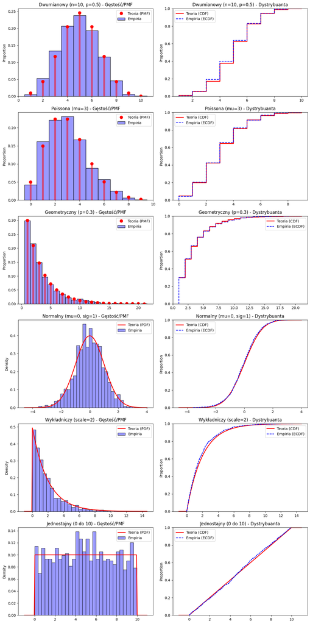

|  | Rozkład | Śr. Teoretyczna | Śr. Empiryczna | War. Teoretyczna | War. Empiryczna |
| --- | --- | --- | --- | --- | --- |
| 0 | Dwumianowy (n=10, p=0.5) | 5.0000 | 4.9390 | 2.5000 | 2.4918 |
| 1 | Poissona (mu=3) | 3.0000 | 2.9790 | 3.0000 | 2.8674 |
| 2 | Geometryczny (p=0.3) | 3.3333 | 3.3620 | 7.7778 | 8.1091 |
| 3 | Normalny (mu=0, sig=1) | 0.0000 | -0.0534 | 1.0000 | 0.9992 |
| 4 | Wykładniczy (scale=2) | 2.0000 | 1.8410 | 4.0000 | 3.5211 |
| 5 | Jednostajny (0 do 10) | 5.0000 | 4.9587 | 8.3333 | 7.9342 |

```python
np.random.seed(42)
N = 1000
rozklady = {
    'Dwumianowy (n=10, p=0.5)': {'typ': 'dyskretny', 'dist': binom(n=10, p=0.5)},
    'Poissona (mu=3)': {'typ': 'dyskretny', 'dist': poisson(mu=3)},
    'Geometryczny (p=0.3)': {'typ': 'dyskretny', 'dist': geom(p=0.3)},
    'Normalny (mu=0, sig=1)': {'typ': 'ciagly', 'dist': norm(loc=0, scale=1)},
    'Wykładniczy (scale=2)': {'typ': 'ciagly', 'dist': expon(scale=2)},
    'Jednostajny (0 do 10)': {'typ': 'ciagly', 'dist': uniform(loc=0, scale=10)}
}

wyniki = []
fig, axes = plt.subplots(len(rozklady), 2, figsize=(12, 4 * len(rozklady)))

for i, (nazwa, info) in enumerate(rozklady.items()):
    dist = info['dist']
    typ = info['typ']

    probka = dist.rvs(size=N)

    mean_teo, var_teo = dist.stats(moments='mv')
    mean_emp = np.mean(probka)
    var_emp = np.var(probka, ddof=1)

    wyniki.append({
        'Rozkład': nazwa,
        'Śr. Teoretyczna': float(mean_teo),
        'Śr. Empiryczna': mean_emp,
        'War. Teoretyczna': float(var_teo),
        'War. Empiryczna': var_emp
    })

    ax_pdf = axes[i, 0]
    ax_cdf = axes[i, 1]

    x_min, x_max = probka.min(), probka.max()

    if typ == 'dyskretny':
        x = np.arange(x_min, x_max + 1)

        ax_pdf.plot(x, dist.pmf(x), 'ro', ms=8, label='Teoria (PMF)')
        ax_pdf.vlines(x, 0, dist.pmf(x), colors='r', lw=5, alpha=0.5)
        ax_cdf.step(x, dist.cdf(x), where='post', color='r', label='Teoria (CDF)', lw=2)
        sns.histplot(probka, stat='proportion', discrete=True, color='blue', alpha=0.4, ax=ax_pdf, label='Empiria')
        sns.ecdfplot(probka, ax=ax_cdf, color='blue', linestyle='--', label='Empiria (ECDF)')

    else:
        x = np.linspace(x_min - 1, x_max + 1, 200)

        ax_pdf.plot(x, dist.pdf(x), 'r-', lw=2, label='Teoria (PDF)')
        ax_cdf.plot(x, dist.cdf(x), 'r-', lw=2, label='Teoria (CDF)')

        sns.histplot(probka, stat='density', bins=30, color='blue', alpha=0.4, ax=ax_pdf, label='Empiria')
        sns.ecdfplot(probka, ax=ax_cdf, color='blue', linestyle='--', label='Empiria (ECDF)')

    ax_pdf.set_title(f'{nazwa} - Gęstość/PMF')
    ax_pdf.legend()
    ax_cdf.set_title(f'{nazwa} - Dystrybuanta')
    ax_cdf.legend()

plt.tight_layout()
plt.show()

df_wyniki = pd.DataFrame(wyniki).round(4)
df_wyniki
```

Wyniki pokazują, że dla wszystkich rozkładów empiryczne wartości średniej i wariancji są zbliżone do teoretycznych. Wykresy gęstości oraz dystrybuanty pokazują dobrą zgodność między rozkładami teoretycznymi a empirycznymi.